# Assignment 14 - Optional: Writing a function - Loop

*How to do it?*:

- Open the Rmarkdown file of this assignment (link) in Rstudio.
- Right under each **question**, insert a code chunk (you can use the hotkey `Ctrl + Alt + I` to add a code chunk) and code the solution for the question.
- `Knit` the rmarkdown file (hotkey: `Ctrl + Alt + K`) to export an html.
- Publish the html file to your Githiub Page.

*Submission*: Submit the link on Github of the assignment to Canvas

1. Write the following function. Give examples to test your function.
- Input: a data frame
- Output: a data frame with all the missing of numeric variables replaced by the associated means.

Hint: [Similar function](https://bryantstats.github.io/math421/gganimate/18_writing_functions.html#28)

```r
numeric_mean_impute <- function(d) {
  for (i in 1:length(d)) {
    if (is.numeric(d[[i]])) {

      mean_val <- mean(d[[i]], na.rm = TRUE)
      d[[i]][is.na(d[[i]])] <- mean_val

    }
  }
  return(d)
}

df <- data.frame(
  age = c(20, 25, NA, 30),
  income = c(50000, NA, 60000, 55000),
  gender = c("M", "F", "F", "M")
)

numeric_mean_impute(df)
```

```
##   age income gender
## 1  20  50000      M
## 2  25  55000      F
## 3  25  60000      F
## 4  30  55000      M
```

```r
df2 <- data.frame(
  x = c(1, 2, 3),
  y = c(4, 5, 6)
)

numeric_mean_impute(df2)
```

```
##   x y
## 1 1 4
## 2 2 5
## 3 3 6
```

```r
df3 <- data.frame(
  a = c(NA, NA, NA),
  b = c(1, 2, NA)
)

numeric_mean_impute(df3)
```

```
##    a   b
## 1 NA 1.0
## 2 NA 2.0
## 3 NA 1.5
```

2. Write the following function. Give examples to test your function.
- Input: a data frame
- Output: a data frame with all the missing of variables replaced by the associated means (for numeric variables) or modes (for non-numeric variables).

Hint: Use If-statement to combine the function in Problem 1 and the function in [this example](https://bryantstats.github.io/math421/gganimate/18_writing_functions.html#28)

```r
mode_impute <- function(x) {
  ux <- na.omit(x)
  ux[which.max(tabulate(match(ux, ux)))]
}
mean_mode_impute <- function(d) {
  for (i in 1:length(d)) {
    if (is.numeric(d[[i]])) {
      mean_val <- mean(d[[i]], na.rm = TRUE)
      d[[i]][is.na(d[[i]])] <- mean_val

    } else {
      mode_val <- mode_impute(d[[i]])
      d[[i]][is.na(d[[i]])] <- mode_val
    }
  }
  return(d)
}

df <- data.frame(
  age = c(20, 25, NA, 30),
  income = c(50000, NA, 60000, 55000),
  gender = c("M", "F", NA, "M"),
  stringsAsFactors = FALSE
)

mean_mode_impute(df)
```

```
##   age income gender
## 1  20  50000      M
## 2  25  55000      F
## 3  25  60000      M
## 4  30  55000      M
```

```r
df2 <- data.frame(
  x = c(1, 2, NA, 4),
  y = c(NA, 5, 6, 7)
)

mean_mode_impute(df2)
```

```
##          x y
## 1 1.000000 6
## 2 2.000000 5
## 3 2.333333 6
## 4 4.000000 7
```

```r
df3 <- data.frame(
  color = c("red", "blue", NA, "red"),
  type = c("A", NA, "A", "B"),
  stringsAsFactors = FALSE
)

mean_mode_impute(df3)
```

```
##   color type
## 1   red    A
## 2  blue    A
## 3   red    A
## 4   red    B
```

3. Write the following function. Give examples to test your function.
- Input: a data frame
- Output: Bar plots of all non-numeric variables

Hint: [Similar function](https://bryantstats.github.io/math421/gganimate/18_writing_functions.html#33)

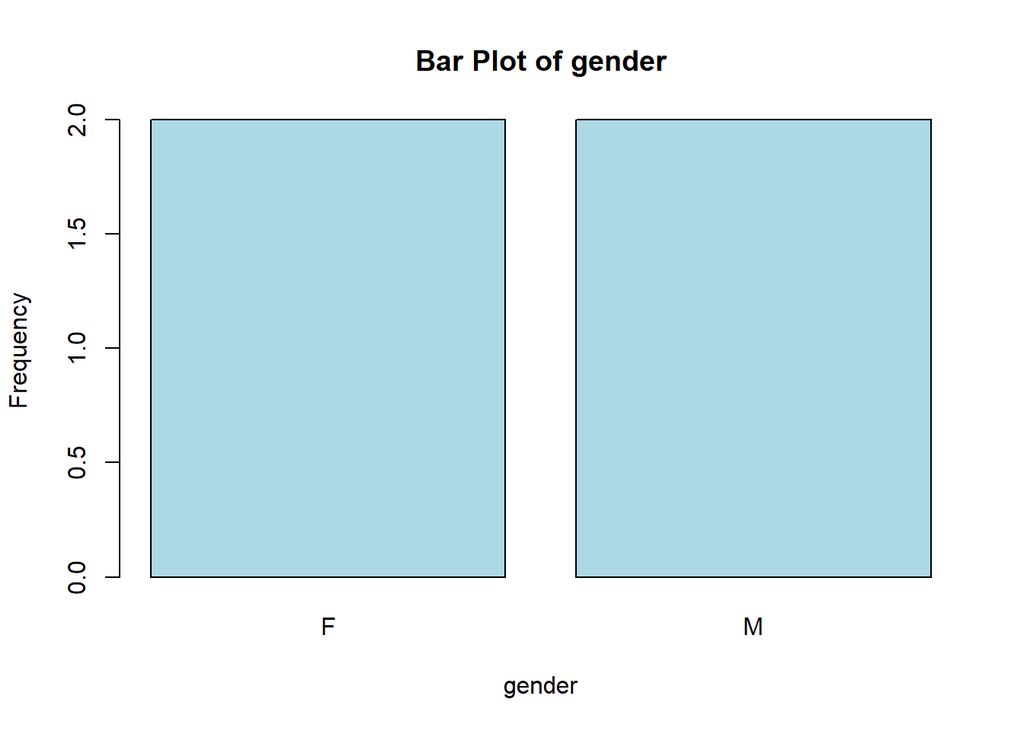

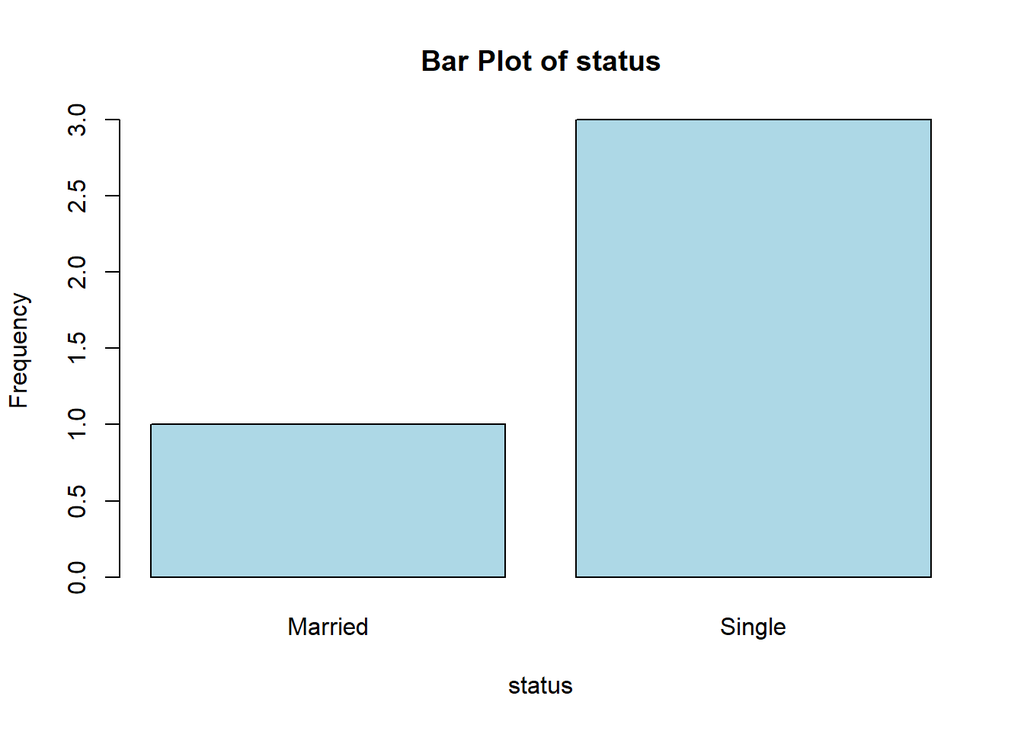

```r
barplot_non_numeric <- function(d) {

  for (i in 1:length(d)) {
    if (!is.numeric(d[[i]])) {

      barplot(
        table(d[[i]]),
        main = paste("Bar Plot of", names(d)[i]),
        xlab = names(d)[i],
        ylab = "Frequency",
        col = "lightblue"
      )
    }
  }
}

df <- data.frame(
  age = c(20, 25, 30, 40),
  gender = c("M", "F", "F", "M"),
  status = c("Single", "Married", "Single", "Single"),
  income = c(50000, 60000, 55000, 65000),
  stringsAsFactors = FALSE
)

barplot_non_numeric(df)
```

4. Write the following function. Give examples to test your function.
- Input: a data frame
- Output: all possible the bar plots of a non-numeric variable filled by a non-numeric variable.

Hint: [Similar function](https://bryantstats.github.io/math421/gganimate/18_writing_functions.html#40)

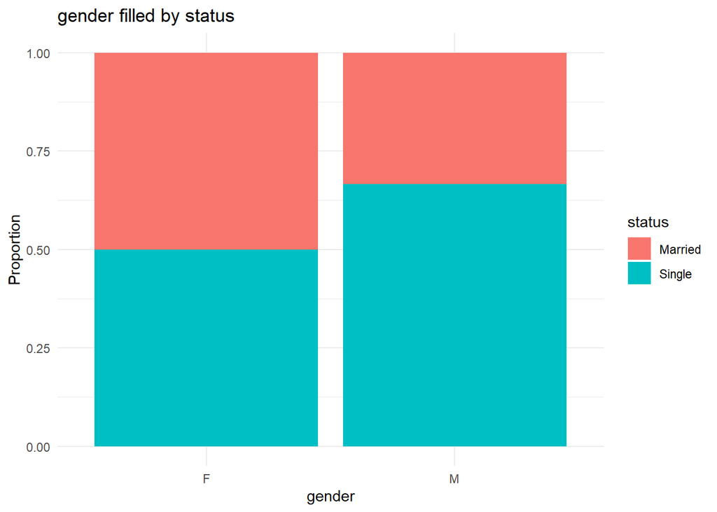

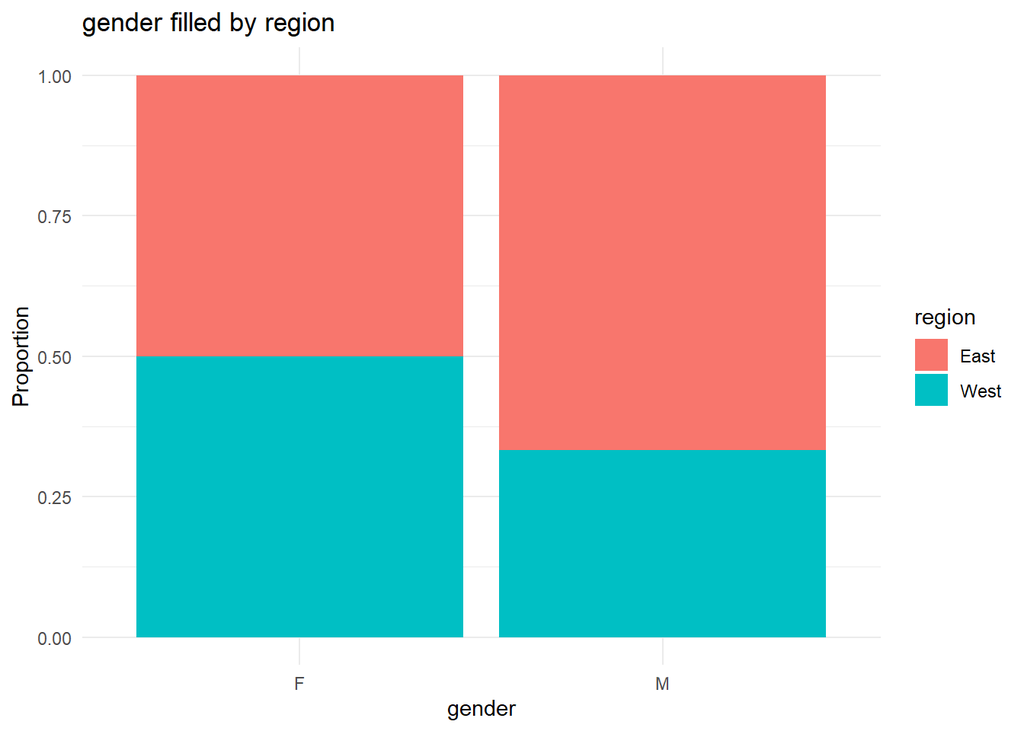

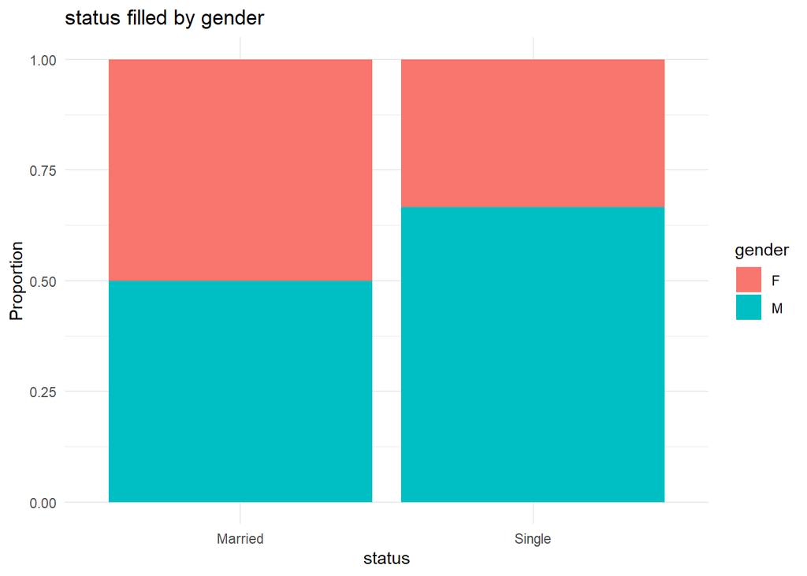

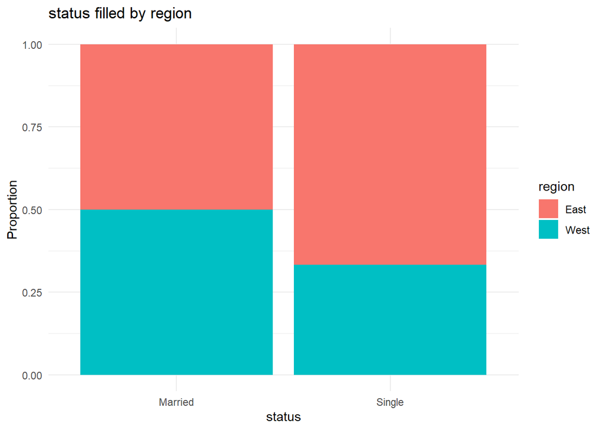

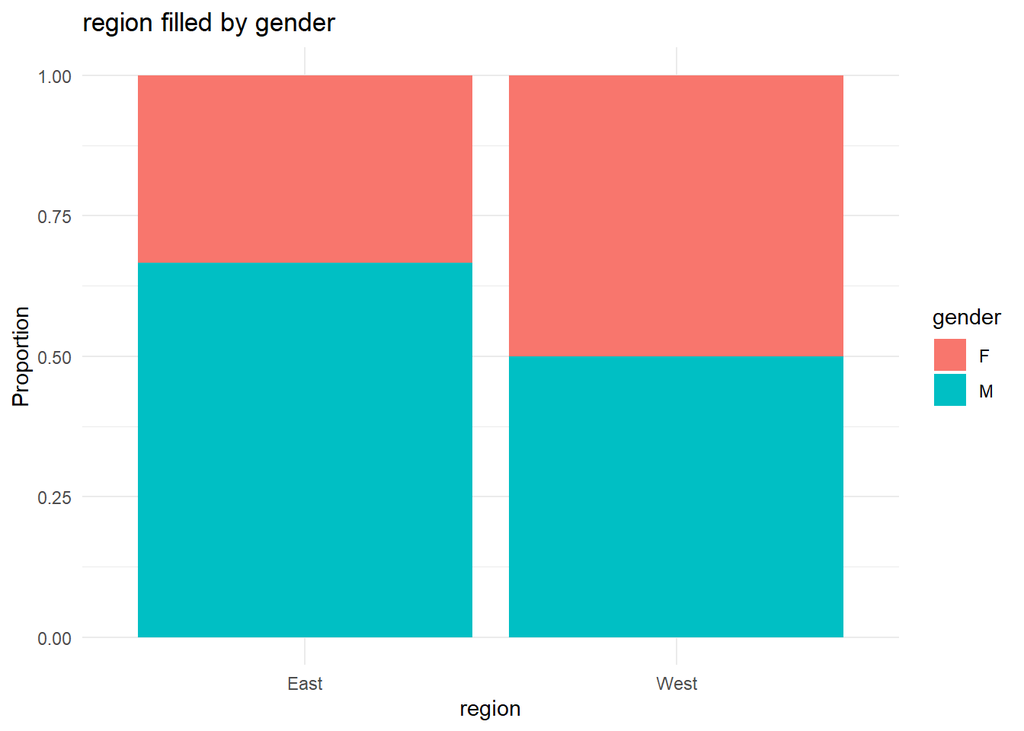

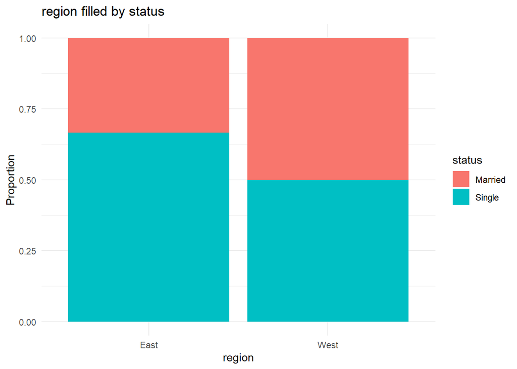

```r
filled_barplot_non_numeric <- function(d) {
  non_num_cols <- names(d)[!sapply(d, is.numeric)]
  for (i in 1:length(non_num_cols)) {
    for (j in 1:length(non_num_cols)) {

      if (i != j) {
        print(
          ggplot(d, aes(x = .data[[non_num_cols[i]]],
                        fill = .data[[non_num_cols[j]]])) +
            geom_bar(position = "fill") +
            labs(
              title = paste(non_num_cols[i], "filled by", non_num_cols[j]),
              x = non_num_cols[i],
              y = "Proportion",
              fill = non_num_cols[j]
            ) +
            theme_minimal()
        )
      }
    }
  }
}

library(ggplot2)

df <- data.frame(
  gender = c("M", "F", "F", "M", "M"),
  status = c("Single", "Married", "Single", "Single", "Married"),
  region = c("East", "West", "East", "West", "East"),
  age = c(22, 35, 28, 40, 30),
  stringsAsFactors = FALSE
)

filled_barplot_non_numeric(df)
```

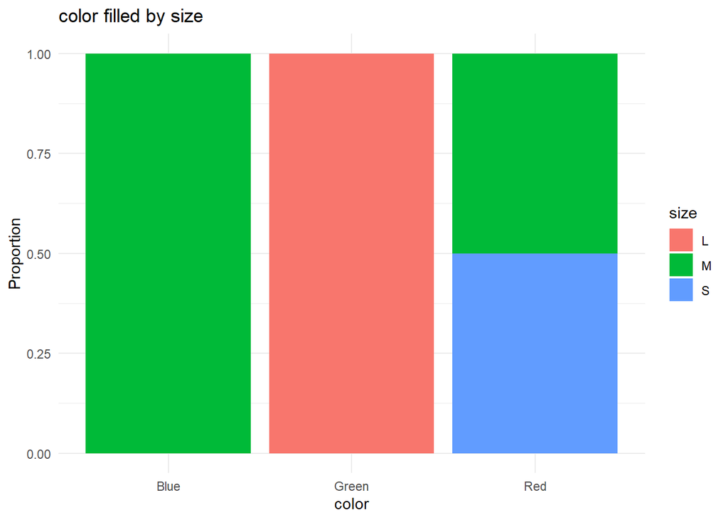

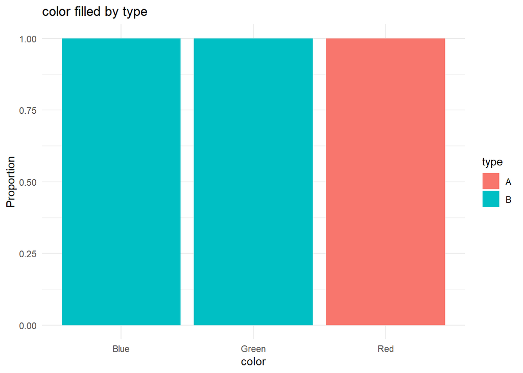

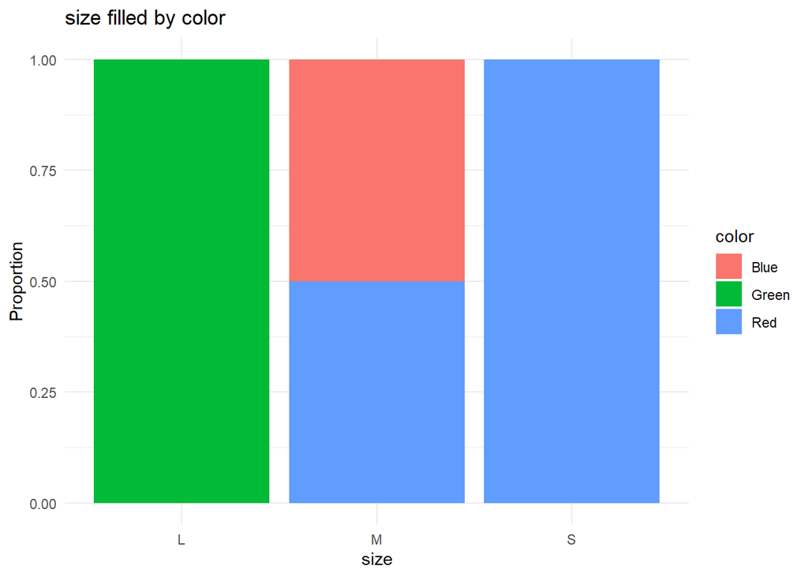

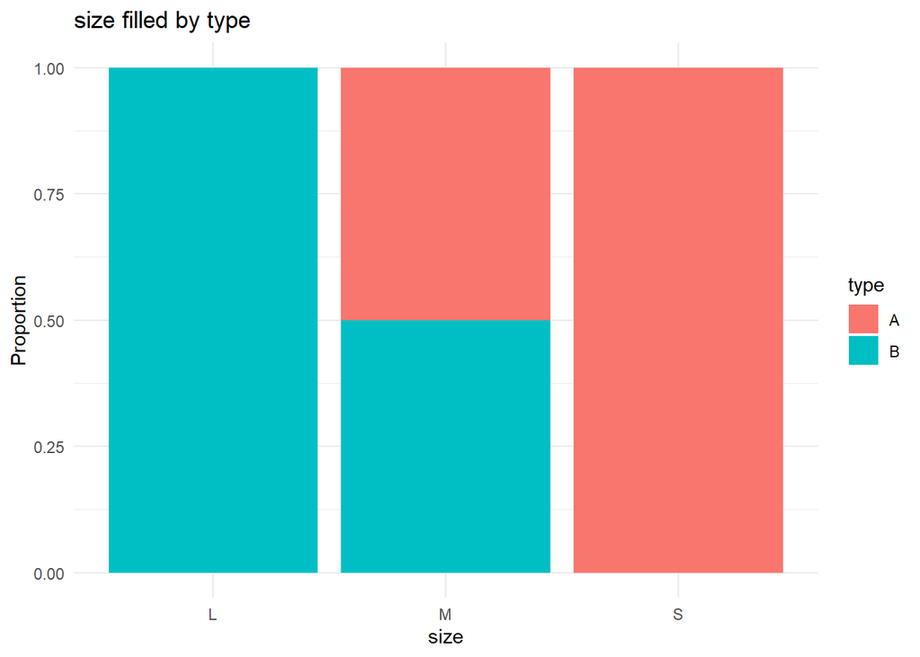

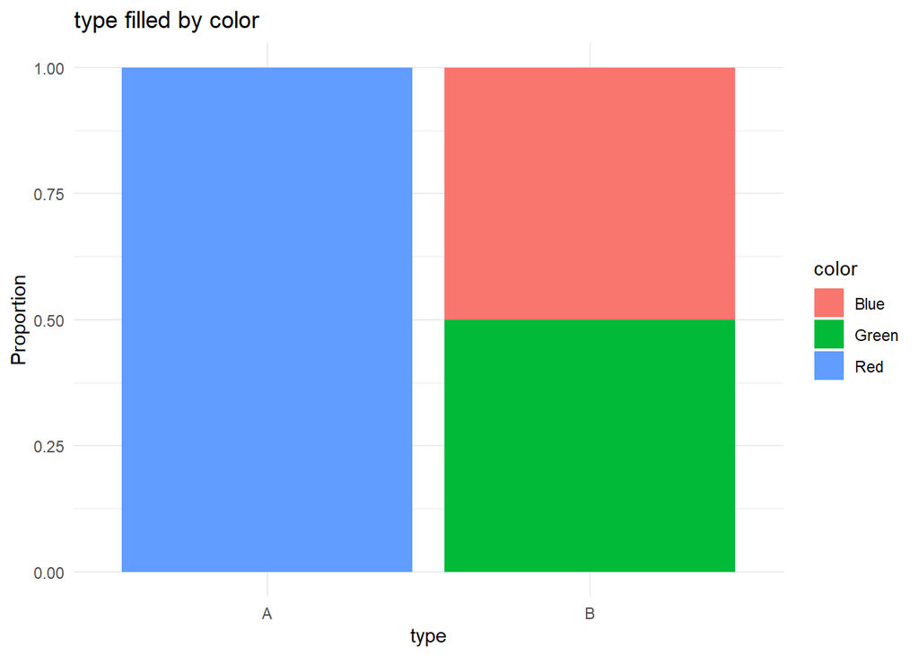

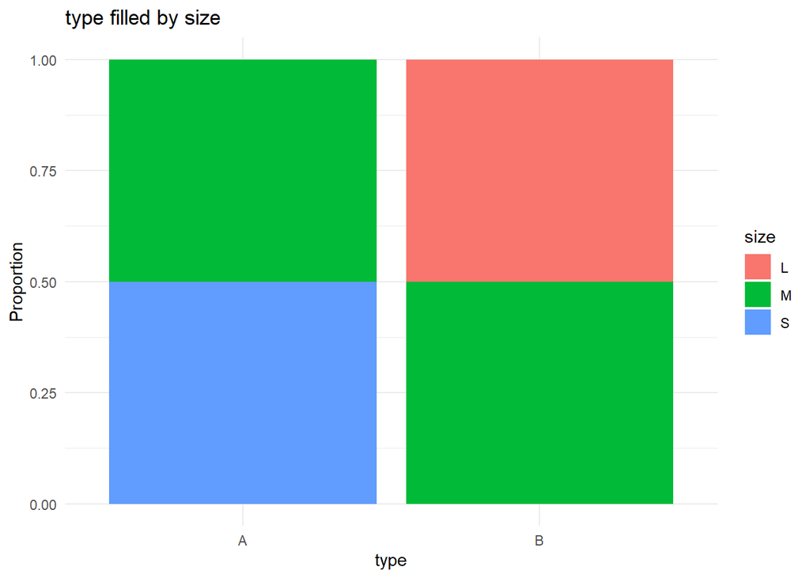

```r
df2 <- data.frame(
  color = c("Red", "Blue", "Red", "Green"),
  size = c("S", "M", "M", "L"),
  type = c("A", "B", "A", "B"),
  stringsAsFactors = FALSE
)

filled_barplot_non_numeric(df2)
```

5. Write the following function. Give examples to test your function.
- Input: a data frame
- Output:
  - all possible the bar plots of a non-numeric variable filled by a non-numeric variable.
  - all possible the density plots of a numeric variable colored by a non-numeric variable
  - all possible the scatter plots.

Hint: Combine [this function](https://bryantstats.github.io/math421/gganimate/18_writing_functions.html#37), [this function](https://bryantstats.github.io/math421/gganimate/18_writing_functions.html#40), and the function in Question 4. One way to combine is creating a new function, `quick_plot`, and call these three functions within `quick_plot`.

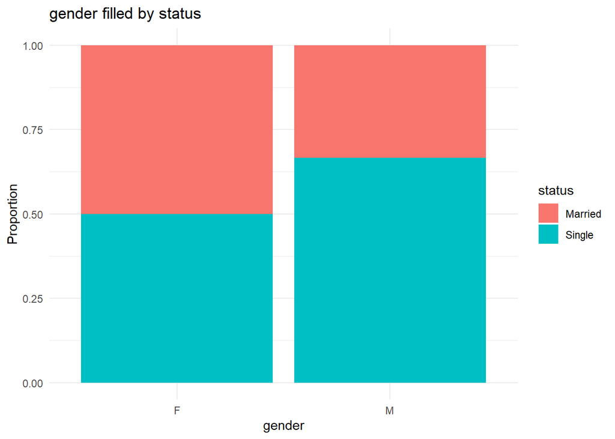

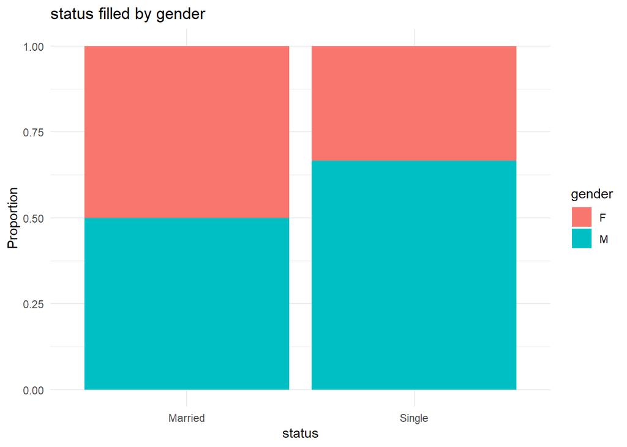

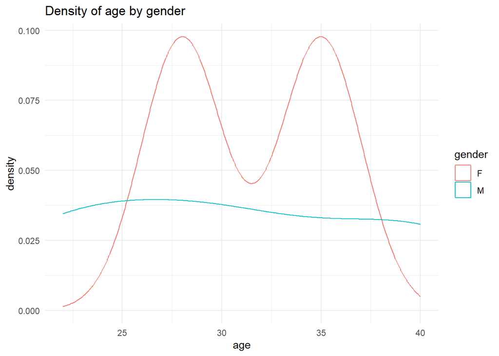

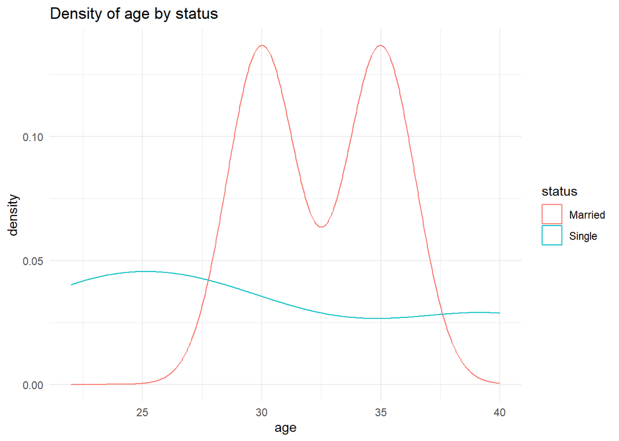

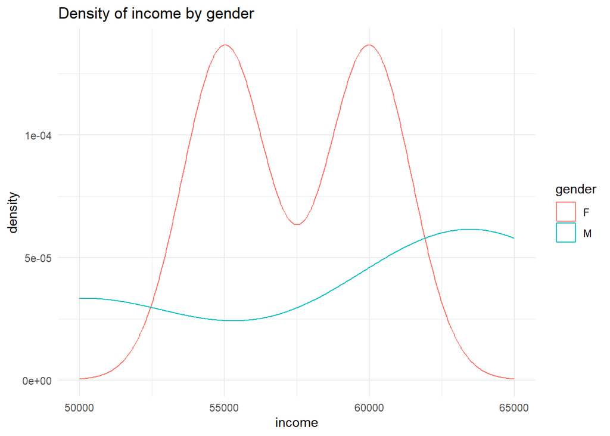

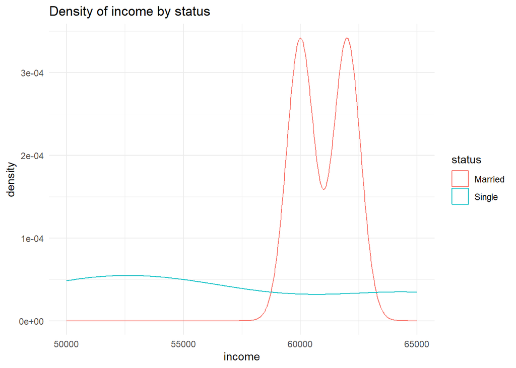

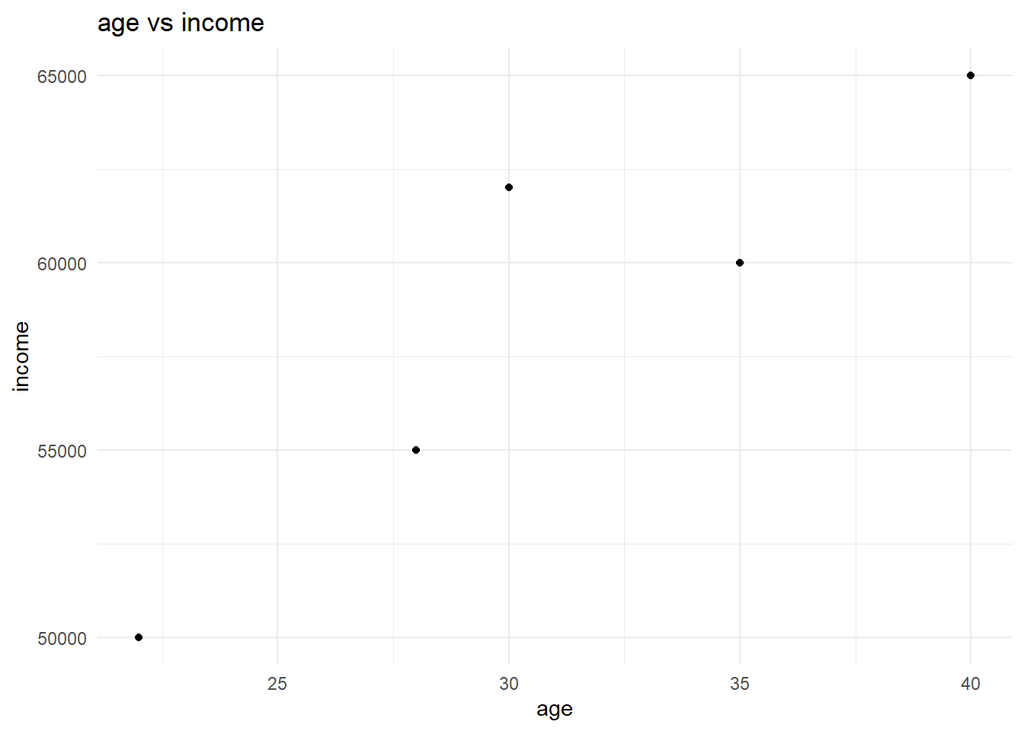

```r
all_possible_plots <- function(d) {

  library(ggplot2)

  num_vars <- names(d)[sapply(d, is.numeric)]
  non_num_vars <- names(d)[!sapply(d, is.numeric)]
  if (length(non_num_vars) >= 2) {
    for (i in 1:length(non_num_vars)) {
      for (j in 1:length(non_num_vars)) {
        if (i != j) {
          print(
            ggplot(d, aes(x = .data[[non_num_vars[i]]],
                          fill = .data[[non_num_vars[j]]])) +
              geom_bar(position = "fill") +
              labs(
                title = paste(non_num_vars[i], "filled by", non_num_vars[j]),
                x = non_num_vars[i],
                y = "Proportion",
                fill = non_num_vars[j]
              ) +
              theme_minimal()
          )
        }
      }
    }
  }

  if (length(num_vars) >= 1 && length(non_num_vars) >= 1) {
    for (i in num_vars) {
      for (j in non_num_vars) {
        print(
          ggplot(d, aes(x = .data[[i]],
                        color = .data[[j]])) +
            geom_density() +
            labs(
              title = paste("Density of", i, "by", j),
              x = i,
              color = j
            ) +
            theme_minimal()
        )
      }
    }
  }

  if (length(num_vars) >= 2) {
    for (i in 1:(length(num_vars) - 1)) {
      for (j in (i + 1):length(num_vars)) {
        print(
          ggplot(d, aes(x = .data[[num_vars[i]]],
                        y = .data[[num_vars[j]]])) +
            geom_point() +
            labs(
              title = paste(num_vars[i], "vs", num_vars[j]),
              x = num_vars[i],
              y = num_vars[j]
            ) +
            theme_minimal()
        )
      }
    }
  }
}

df <- data.frame(
  age = c(22, 35, 28, 40, 30),
  income = c(50000, 60000, 55000, 65000, 62000),
  gender = c("M", "F", "F", "M", "M"),
  status = c("Single", "Married", "Single", "Single", "Married"),
  stringsAsFactors = FALSE
)

all_possible_plots(df)
```

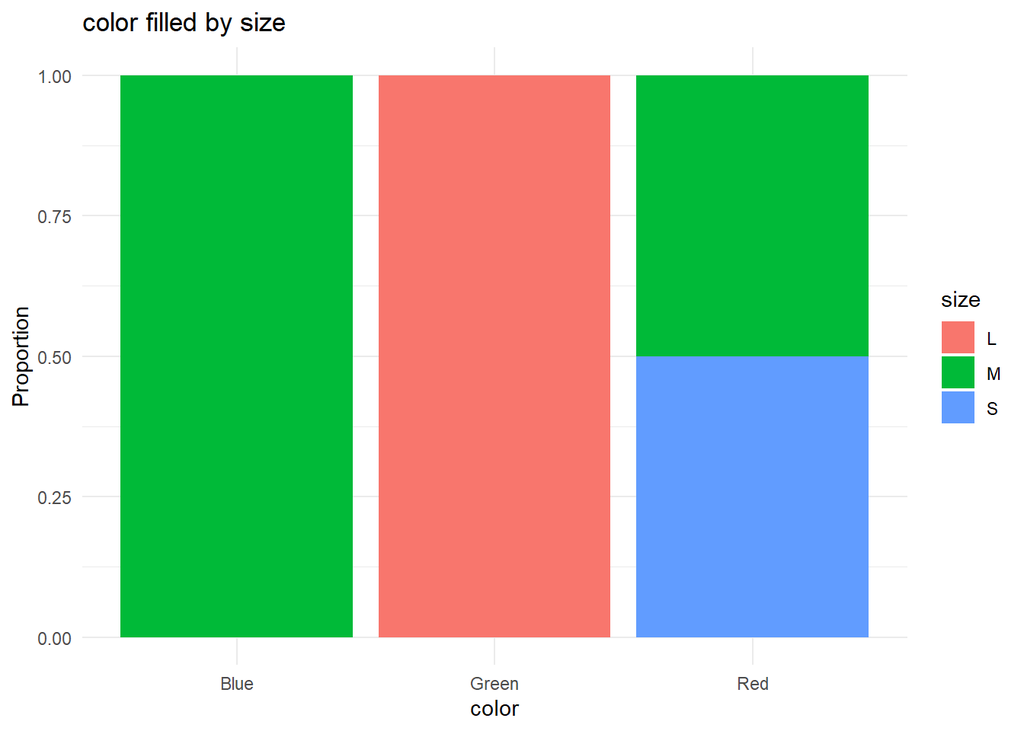

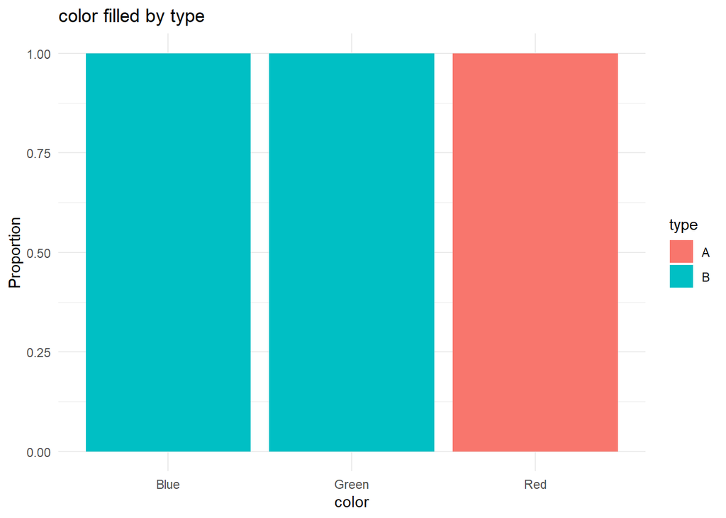

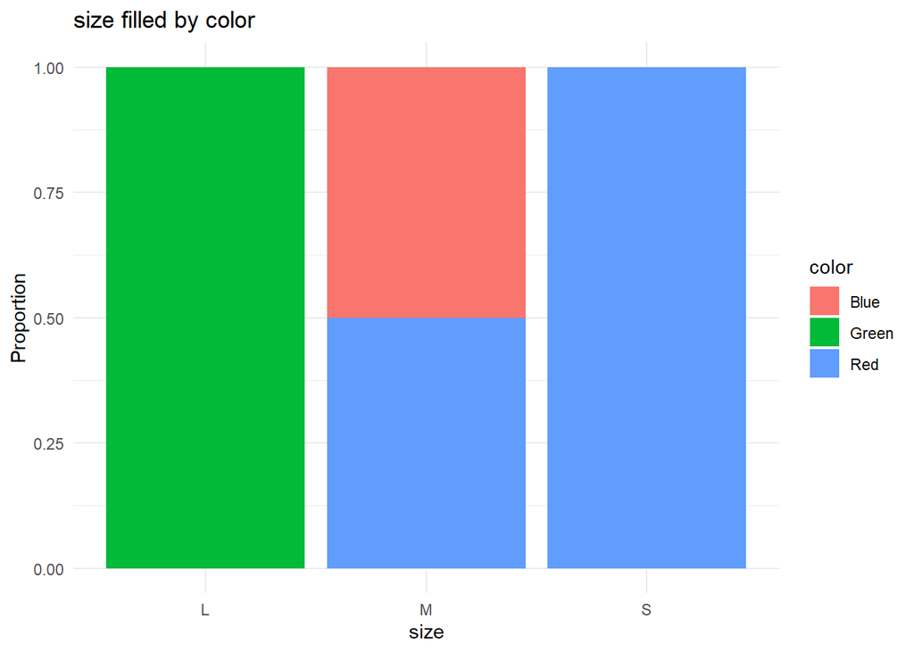

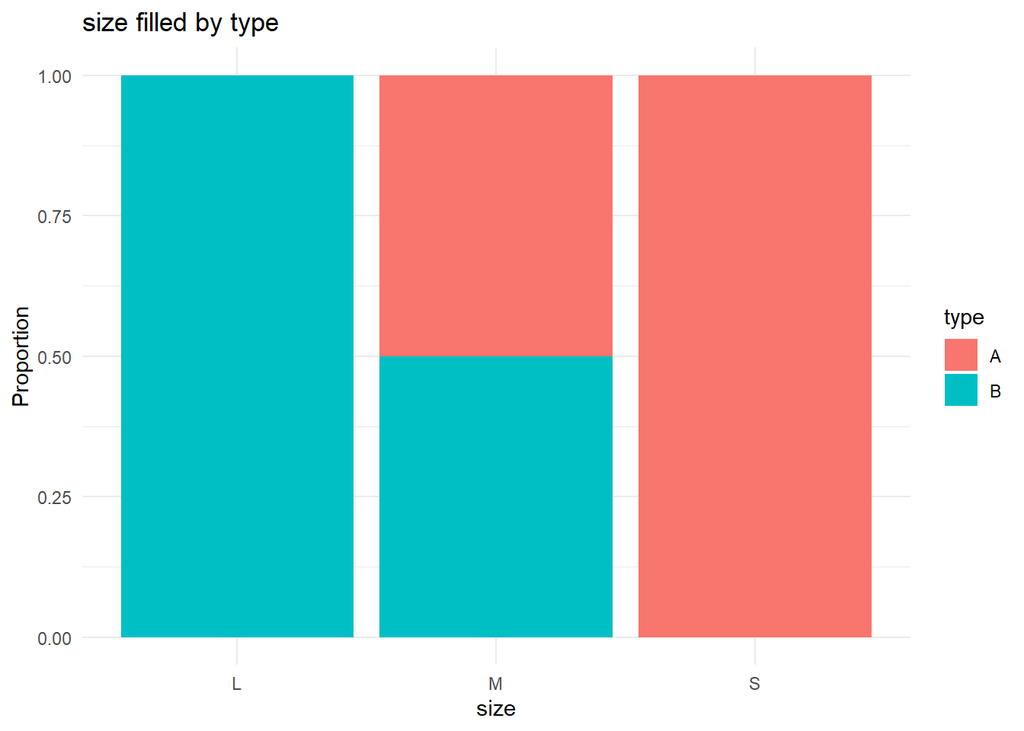

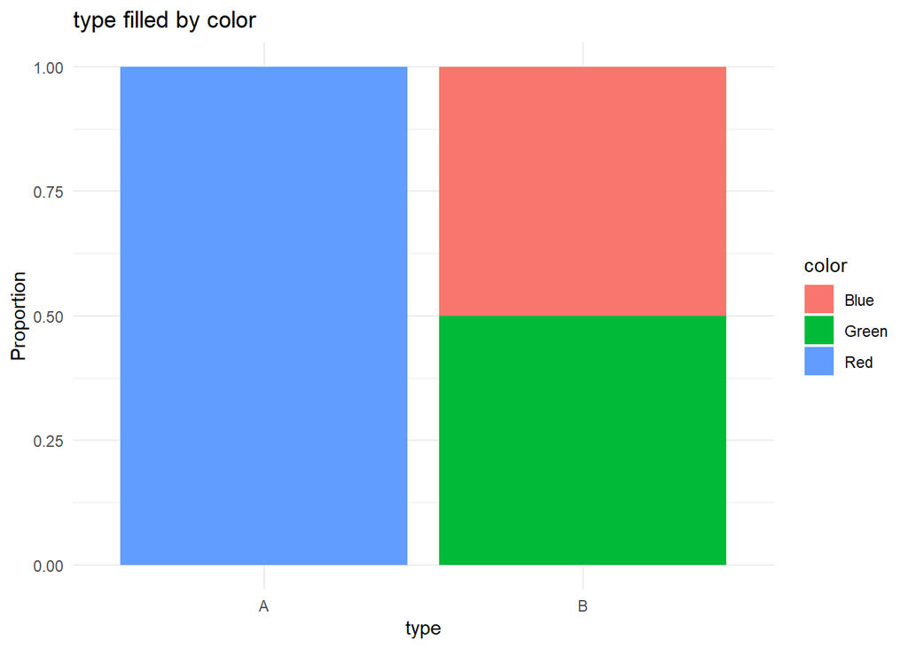

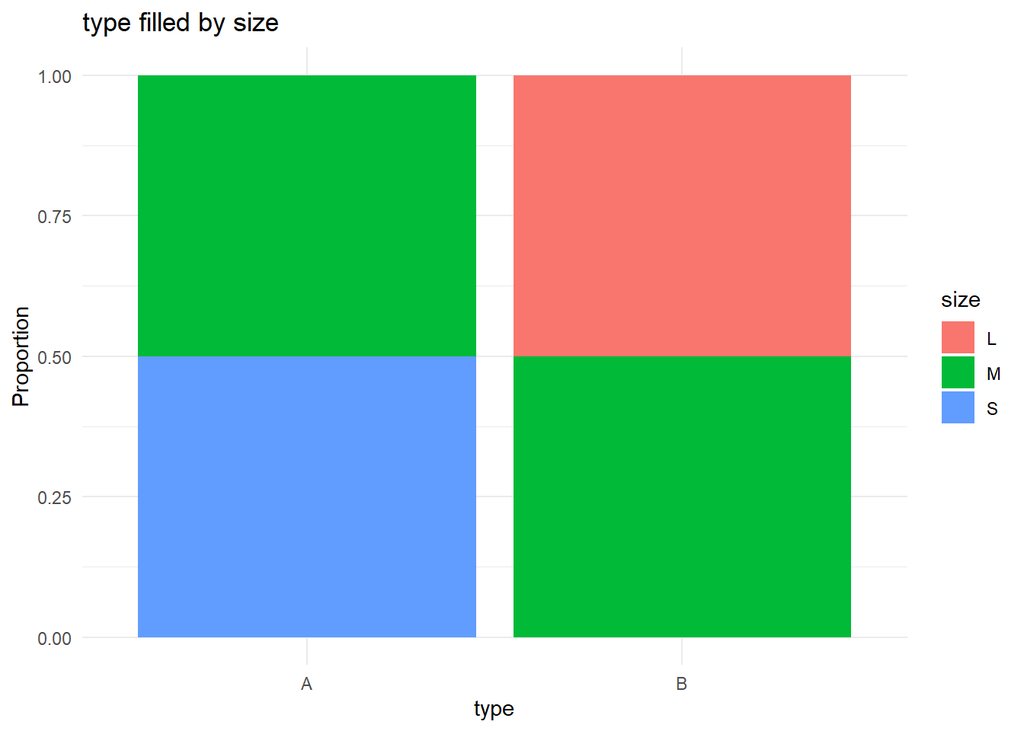

```r
df2 <- data.frame(
  color = c("Red", "Blue", "Red", "Green"),
  size = c("S", "M", "M", "L"),
  type = c("A", "B", "A", "B"),
  stringsAsFactors = FALSE
)

all_possible_plots(df2)
```

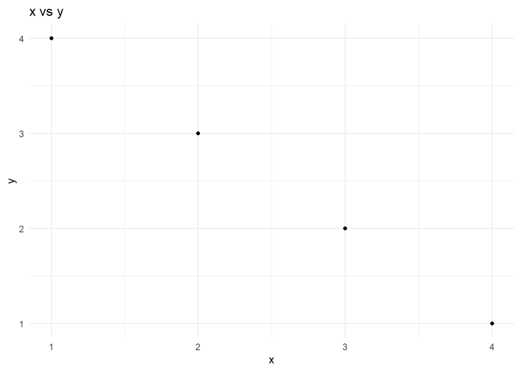

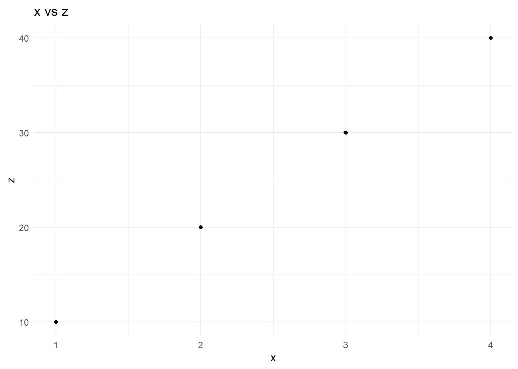

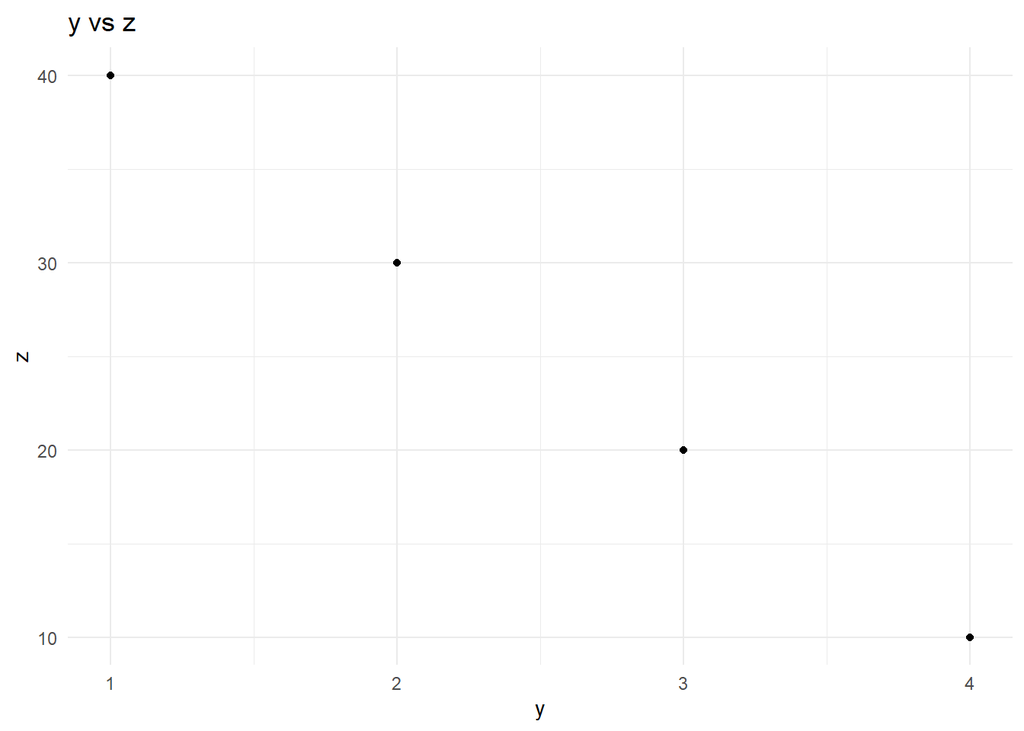

```r
df3 <- data.frame(
  x = c(1, 2, 3, 4),
  y = c(4, 3, 2, 1),
  z = c(10, 20, 30, 40)
)

all_possible_plots(df3)
```